# PRÁCTICA 5 CAÍDA LIBRE

**Autor responsable:** Pablo Corbalán de Concepción

**Autores**: Pablo Corbalán de Concepción y Víctor Mula Navarro.

**Grupo:** G4 - DTIE.

**Fecha del informe:** 12/03/2026.

## INFORMACIÓN GENERAL DEL LABORATORIO

**Fecha de realización de la práctica:** 05/03/2026.

**Temperatura:** 18.1ºC

**Humedad relativa:** 66%

**Presión:** 1020.4 hPa

## 1. INTRODUCCIÓN Y OBJETIVOS

Cuando se deja caer un cuerpo desde una determinada altura, este se ve sometido a la fuerza de la gravedad que induce sobre él un movimiento uniformemente acelerado en ausencia de otras fuerzas externas. El estudio de este movimiento es de gran relevancia en la mecánica clásica pues modela muchas situaciones físcas comunes en el día a día. En general, este tipo de movimiento depende únicamente de la fuerza de la gravedad así como de la velocidad inicial que se le induce al cuerpo cuando se deja caer. Normalmente, se toma un sistema de referencia de tal forma que la aceleración de la gravedad se supone con signo negativo y, por tanto, si la velocidad inicial va en su misma dirección, compartirá dicho signo.

La importancia de fijar un sistema de referencia adecuado no es nimia, puesto que a la hora de hacer mediciones experimentales en laboratorio, conviene elegirlo de tal forma que minimice el error humano que puede haber cuando se toman medidas. En particular, fijar el instante de tiempo inicial adecuado hará que el tiempo de reacción que interviene al medir tiempos se minimice y, por tanto, no afecte a la calidad del experimento. Asimismo, convendrá pues fijar una altura de referencia que facilite la modelización del experimento; normalmente se toma como tal el suelo del laboratorio aunque en otras ocasiones una elección distinta se efectuará por los motivos mencionados con anterioridad.

Por consiguiente, esta práctica tiene como objetivos el estudio del movimiento en caída libre de un cuerpo en dos supuestos diferentes: velocidad inicial nula y velocidad inicial no nula. En el primer caso, se estudiará la relación lineal que existe entre el tiempo de caída al cuadrado y la altura sobre la que se deja caer el cuerpo para, mediante una regresión lineal, hallar experimentalmente el valor de la aceleración de la gravedad. Para el segundo supuesto, se hará una regresión no lineal, obteniendo mediante ella el valor de la velocidad inicial que adquirió el cuerpo en el experimento así como un segundo valor de la aceleración de la gravedad. Por tanto, la práctica tiene como objetivos secundarios el manejo de la aplicación audacity para las mediciones de los intervalos de tiempo así como la realización de ajustes lineales y no lineales por mínimos cuadrados.

## 2. MARCO TEÓRICO GENERAL

Como se ha mencionado en la introducción, el objetivo principal es el estudio de un cuerpo en caída libre. La ecuación que utilizaremos para modelar su movimiento es la siguiente:

$$ z(t) = z_0 -v_0\cdot t - \frac{1}{2}g\cdot t^2 \tag{1}$$

siendo $z_0$, $v_0$ la altura y velocidad incial, respectivamente. El eje de alturas se ha orientado con sus valores positivos hacia arriba, de ahí que $g$ y $v_0$ aparezcan con el signo negativo en la ecuación. Si suponemos $v_0 = 0$ y calculamos el tiempo que tarda el cuerpo en caer al suelo $z = 0$, obtenemos:

$$ t^2 = \frac{2}{g} z_0 \tag{2}$$

De esta forma, obtenemos una relación lineal entre la altura inicial y el tiempo de caída, cuya pendiente viene dada por $ a = \frac{2}{g} $ y su ordenada en el origen $b \approx 0$. Expermientalmente, introduciremos una bola metálica pequeña dentro de un globo, el cual fijaremos a una altura dada con la ayuda de un metro. Cuidadosamente para no inducir velocidad inicial alguna, se pinchará el globo y, con la aplicación Audacity se registrarán los intervalos de tiempo en los que el globo explota y la bola impacta con la plataforma metálica que se encuentra bajo el metro. Así determinaremos $t$, y $z_0$ será la altura a la que se pone el globo.

Para la experiencia de caída libre con velocidad inicial no nula, consideremos el movimiento de una bola-imán que cae a través de un tubo rodeado de expiras de cobre. Si $z_0'$ es la posición de vertical de la primera espira con respecto a la base del tubo, $v_0$ la velocidad de la bola al pasar por dicha espira y $t_0'$ el instante de tiempo en el que atraviesa la primera espira, entonces:

$$ z'(t') = z_0' +v_0\cdot (t'-t_0) + \frac{1}{2}g \cdot {(t'-t_0')}^2 \tag{3}$$

donde se ha tomado el eje de alturas orientado con sus valores positivos hacia abajo. Como origen de alturas, se tomará la primera espira $z_0' = 0$, de manera que la altura resulta $z = z' - z_0'$. En cuanto al origen de tiempos, se elige el insante $t_0'$ como origen, por tanto, $t = t' -t_0'$. Si escribimos la inversa de $(3)$:

$$ t = \frac{-v_0 + \sqrt{v_0^2 + 2\cdot g \cdot z}}{g} \tag{4}$$

obtenemos la ecuación buscada para realizar el ajuste no lineal de $t$ frente a $z$ para obtener $v_0$ y $g$

### 2.1 INSTRUMENTACIÓN

Los instrumentos utilizados en este experimento han sido los siguientes:

- **Bolita metálica**: Cuerpo empleado para el estudio de la experiencia 1.
- **Poste vertical con cinta métrica adosada y base metálica**: Utilizado para medir la altura a la que se coloca el globo con la bolita metálica. La cinta métrica tenía como resolución $0.1 cm$
- **Tubo con espiras de cobre**: Empleado en la experiencia 2.
- **Metro**: Utilizado para determinar la altura de cada espira enrrollada alrededor del tubo. De resolución $0.1 cm$.
- **Audacity y tarjeta de sonido**: Utilizados en la determinación de los tiempos tanto para la experiencia 1 como para la 2. El programa Audacity tiene una resolución digital de $0.001 s$.

## 3.RESULTADOS

### 3.1 EXPERIENCIA 1

#### 3.1.1 MEDIDAS DIRECTAS

En esta parte del experimento, se tomaron 10 medidas de altura frente a tiempo de caída. Al trabajar grupalmente, cada grupo de laboratorio anotó una medición de tiempo diferente, de ahí que se tengan 5 tiempos para una altura dada. Este hecho nos ayudará a determinar la incertidumbre tipo A asociada a esta magnitud. La tabla de resultados es la siguiente:

| $Medida$ | $z_0$ ($cm$) | $t_1$ ($s$) | $t_2$ ($s$) | $t_3$ ($s$) | $t_4$ ($s$) | $t_5$ ($s$) |
| --- | --- | --- | --- | --- | --- | --- |
| 1 | 176.2 | 0.604 | 0.597 | 0.605 | 0.635 | 0.603 |
| 2 | 145.5 | 0.557 | 0.552 | 0.580 | 0.576 | 0.557 |
| 3 | 117.2 | 0.497 | 0.488 | 0.490 | 0.489 | 0.485 |
| 4 | 166.5 | 0.601 | 0.592 | 0.593 | 0.594 | 0.590 |
| 5 | 105.0 | 0.476 | 0.469 | 0.472 | 0.470 | 0.471 |
| 6 | 91.5 | 0.437 | 0.435 | 0.435 | 0.436 | 0.434 |
| 7 | 134.3 | 0.527 | 0.528 | 0.518 | 0.528 | 0.530 |
| 8 | 68.2 | 0.401 | 0.401 | 0.399 | 0.403 | 0.401 |
| 9 | 43.8 | 0.304 | 0.305 | 0.305 | 0.306 | 0.304 |
| 10 | 14.9 | 0.180 | 0.183 | 0.182 | 0.181 | 0.180 |

Asociada a cada altura, podemos calcular el tiempo medio entre las 5 medidas tomadas de la siguiente forma:

$$ \overline t = \frac{1}{5} \cdot \sum_{i = 1}^{5} t_i$$

Para el cálculo de la incertidumbre, comencemos con la tipo B, asociada en este caso al programa Audacity. Si suponemos una distribución rectangular:

$$ u_B = \frac{\Delta}{\sqrt{12}} = \frac{0.001}{\sqrt{12}} = 0.00029 s$$

Por otro lado, para la tipo A, comenzaremos haciendo el cálculo de las varianzas para cada altura:

$$ s^2 = \frac{1}{4} \sum _{i = 1}^{5} {(t_i - \overline t)}^2$$

De esta forma:

$$ u_A = \frac{s}{\sqrt{5}}$$

Por tanto, la incertidumbre asociada a la medida de los tiempos de caída será:

$$ u_t = \sqrt{u_A^2+u_B^2}$$

Si se ha calculado el tiempo al cuadrado con la siguiente relación $t^2 = (t)^2$, la propagación de incertidumbres nos da:

$$ u_{t^2} = 2\cdot \overline{t^2}\cdot \frac{u_t}{\overline t} = 2\cdot \overline t \cdot u_t$$

#### 3.1.2 AJUSTE POR MÍNIMOS CUADRADOS: $t^2$ FRENTE A $z_0$ Y OBTENCIÓN DEL VALOR DE $g$

Los cálculos detallados de dichos valores han sido realizados en el anexo 6.1. Sus valores son recogidos con las cifras significativas adecuadas en esta tabla, que será la utilizada a la hora de hacer la regresión lineal:

| $Medida$ | $z_0$ ($m$) | $\overline t^2$ ($s^2$) | $u_{t^2}$ ($s^2$) |
| --- | --- | --- | --- |
| 1 | 1.762 | 0.3706 | 0.0082 |
| 2 | 1.455 | 0.3185 | 0.0064 |
| 3 | 1.172 | 0.2399 | 0.0020 |
| 4 | 1.665 | 0.3528 | 0.0022 |
| 5 | 1.050 | 0.2224 | 0.0012 |
| 6 | 0.915 | 0.18957 | 0.00051 |
| 7 | 1.343 | 0.2769 | 0.0022 |
| 8 | 0.682 | 0.16080 | 0.00056 |
| 9 | 0.438 | 0.09290 | 0.00029 |
| 10 | 0.149 | 0.03283 | 0.00024 |

Obteniendo pues la siguiente gráfica:

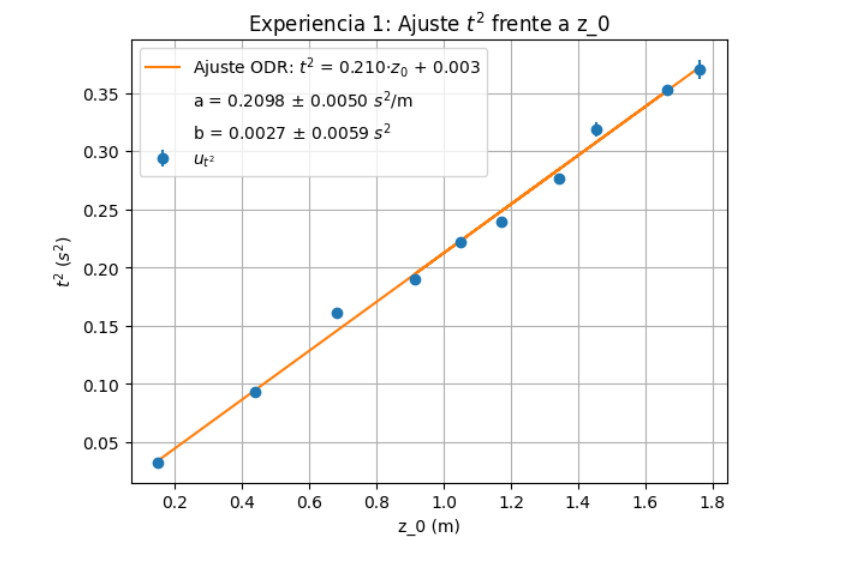

El valor obtenido de la pendiente, con su respectiva incertidumbre es el siguiente:

$$ a = 0.2098 \pm 0.0050 \frac{s^2}{m}$$

Por consiguiente:

$$ g = \frac{2}{a} = \frac{2}{0.2098} = 9.532888 \frac{m}{s^2}$$

Si utilizamos propagación de incertidumbres para hallar el valor de $u_g$ obtenemos:

$$ u_g = g \cdot \frac{u_a}{a} = \frac{2}{a^2}\cdot u_a = \frac{2}{0.2098^2} \cdot 0.0050 = 0.23 \frac{m}{s^2}$$

Finalmente, concluimos:

$$ g = 9.53 \pm 0.23 \frac{m}{s^2}$$

### 3.2 EXPERIENCIA 2

#### 3.2.1 MEDIDAS TOMADAS

Usando el programa Audacity hemos tomado medidas de la caída libre de una bola-imán a lo largo de diez pequeños solenoides conductores de cobre. Este proceso se ha repetido tres veces, obteniendo las siguientes medidas:

| Medida | $z'$ (cm) | $t'_1$ (s) | $t'_2$ (s) | $t'_3$ (s) | $\\|$ | $z$ (cm) | $t_1$ (s) | $t_2$ (s) | $t_3$ (s) | $\bar{t}$ (s) |
| --- | --- | --- | --- | --- | --- | --- | --- | --- | --- | --- |
| 1 | 10.0 | 0.957 | 2.401 | 2.708 | $\\|$ | 0.0 | 0.000 | 0.000 | 0.000 | 0.000 |
| 2 | 18.9 | 1.012 | 2.458 | 2.765 | $\\|$ | 8.9 | 0.055 | 0.057 | 0.057 | 0.056 |
| 3 | 28.1 | 1.055 | 2.502 | 2.809 | $\\|$ | 18.1 | 0.098 | 0.101 | 0.101 | 0.100 |
| 4 | 36.8 | 1.090 | 2.538 | 2.845 | $\\|$ | 26.8 | 0.133 | 0.137 | 0.137 | 0.136 |
| 5 | 45.9 | 1.122 | 2.570 | 2.877 | $\\|$ | 35.9 | 0.165 | 0.169 | 0.169 | 0.168 |
| 6 | 54.9 | 1.151 | 2.599 | 2.906 | $\\|$ | 44.9 | 0.194 | 0.198 | 0.198 | 0.197 |
| 7 | 64.2 | 1.179 | 2.626 | 2.933 | $\\|$ | 54.2 | 0.222 | 0.225 | 0.225 | 0.224 |
| 8 | 73.1 | 1.204 | 2.650 | 2.958 | $\\|$ | 63.1 | 0.247 | 0.249 | 0.250 | 0.249 |
| 9 | 82.1 | 1.227 | 2.674 | 2.981 | $\\|$ | 72.1 | 0.270 | 0.273 | 0.273 | 0.272 |
| 10 | 91.2 | 1.249 | 2.696 | 3.004 | $\\|$ | 81.2 | 0.292 | 0.295 | 0.296 | 0.294 |

Donde la línea vertical separa las medidas directas de las medidas indirectas.

Asociada a cada altura, podemos calcular el tiempo medio entre las 3 medidas tomadas de la siguiente forma:

$$\bar{t} = \frac{1}{3} \cdot \sum_{i = 1}^{3} t_i$$

Para el cálculo de la incertidumbre, comencemos con la tipo B, asociada en este caso al programa Audacity (resolución de 0.001 s). Si suponemos una distribución rectangular:

$$u_B = \frac{\Delta}{\sqrt{12}} = \frac{0.001}{\sqrt{12}} \approx 0.00029 s$$

Por otro lado, para la tipo A, comenzaremos haciendo el cálculo de las varianzas para cada altura:

$$s^2 = \frac{1}{2} \sum_{i = 1}^{3} (t_i - \bar{t})^2$$

De esta forma, la incertidumbre tipo A se obtiene como:

$$u_A = \frac{s}{\sqrt{3}}$$

Por tanto, la incertidumbre combinada asociada a la medida de los tiempos de caída será:

$$u_t = \sqrt{u_A^2 + u_B^2}$$

#### 3.2.2 AJUSTE NO LINEAL

Para la determinación de la aceleración de la gravedad $g$ y la velocidad inicial $v_0$, se ha realizado un ajuste no lineal por mínimos cuadrados ponderados de los tiempos medios medidos ($\bar{t}$) frente a las posiciones verticales ($z$). El modelo físico utilizado corresponde a la solución para el tiempo en un movimiento rectilíneo uniformemente acelerado, definida por la siguiente expresión:

$$t(z) = \frac{-v_0 + \sqrt{v_0^2 + 2gz}}{g}$$

| $z$ (m) | $t \pm u_t$ (s) |
| --- | --- |
| 0.000 | 0.00000 $\pm$ 0.00029 |
| 0.089 | 0.05633 $\pm$ 0.00073 |
| 0.181 | 0.1000 $\pm$ 0.0010 |
| 0.268 | 0.1357 $\pm$ 0.0014 |
| 0.359 | 0.1677 $\pm$ 0.0014 |
| 0.449 | 0.1967 $\pm$ 0.0014 |
| 0.542 | 0.2240 $\pm$ 0.0010 |
| 0.631 | 0.24867 $\pm$ 0.00093 |
| 0.721 | 0.2720 $\pm$ 0.0010 |
| 0.812 | 0.2943 $\pm$ 0.0012 |

Tras efectuar el ajuste por mínimos cuadrados, obtenemos la siguiente gráfica:

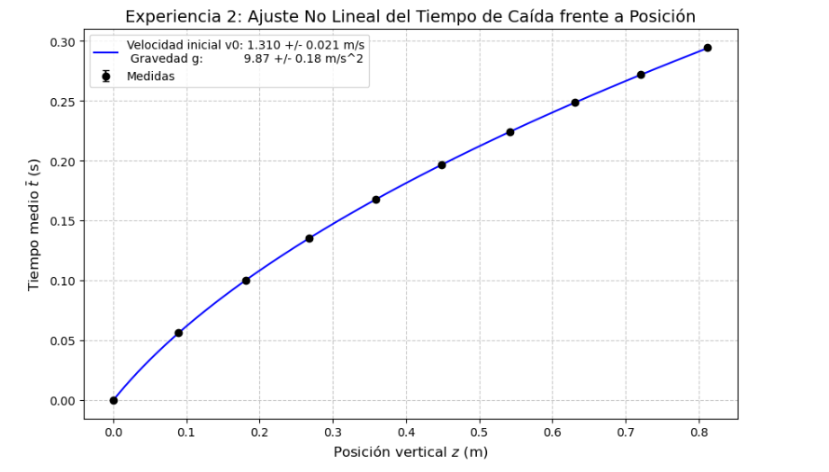

Tras la ejecución del algoritmo, se han obtenido los parámetros optimizados y sus correspondientes incertidumbres (calculadas a partir de la diagonal de la matriz de covarianza). El resultados del ajuste para la velocidad inicial es:

$$v_0 = 1.310 \pm 0.021 \text{ m/s}$$

Asimismo, el valor optimizado para la aceleración de la gravedad resultante del ajuste es:

$$g = 9.87 \pm 0.18 \text{ m/s}^2$$

## 4. CONCLUSIONES

### 4.1 EXPERIENCIA 1

El valor obtenido para la gravedad en la experiencia 1 ha sido de $g = 9.53 \pm 0.23 \frac{m}{s^2}$. Si lo comparamos con el valor bibliográfico $g_{bibliografico} = 9.81 \frac{m}{s^2}$ podemos calcular el error relativo cometido en la experiencia:

$$ \epsilon_g = \frac{g_{experimental} - g_{bibliografico}}{g_{bibliografico}} = \frac{9.53-9.81}{9.81} = -0.0285$$

Cálculo que arroja que se ha cometido un error de aproximadamente $-2.85 \% $ frente al valor de la bibliografía. Esta desviación puede ser debida al tiempo de reacción humano en la medición del tiempo de caída de la bolita o a la resolución imperfecta de los instrumentos de medición utilizados en este experimento, como por ejemplo, la imposibilidad de determinar con precisión la altura a la que se encontraba el globo dada su geometría o variaciones en la medición de la altura del globo debido al uso de una regla milimetrada convencional.

Sin embargo, el porcentaje de error no es muy elevado, por lo que, por otro lado, se puede concluir que la aplicación Audacity resultó ser efectiva en la determinación de intervalos de tiempo pequeños, ya que minimizó el error humano que podría haberse magnificado de haberse medido con cronómetros digitales, debido al tiempo de reacción que existe entre que la bola empieza a caer y se pulsa el botón del cronómetro. Además, el método de punción del globo para no inducir sobre el cuerpo velocidad incial alguna resultó ser adecuado en vistas del poco error cometido en la determinación de la gravedad.

### 4.2 EXPERIENCIA 2

Con los datos obtenidos en la experiencia 2, tras realizar un ajuste por mínimos cuadrados no lineales a la función de posición frente al tiempo, se ha determinado un valor para la aceleración de la gravedad de:

$$g = 9.87 \pm 0.18 m/s^ 2$$

Al contrastar este resultado con el valor bibliográfico de referencia ($9.81$ m/s²), se observa que el error relativo porcentual es de:

$$\epsilon_g = \frac{9.87 - 9.81}{9.81} = 0.0061 $$

Expresado en tanto por uno, es decir un error relativo del $0.61%$. Este resultado representa una mejora significativa en la precisión respecto a la Experiencia reduciendo el error relativo del 2.85% al 0.61%. A diferencia del primer experimento, en esta ocasión se obtuvo una velocidad inicial no nula de $v_0 = 1.310 \pm 0.021$ m/s. En conclusión, la metodología basada en el ajuste no lineal ha demostrado ser más robusta y fiable para la determinación de $g$. La aplicación de Audacity sin ruido de fondo, midiendo únicamente voltaje inducido a través de los solenoides por el imán resulta de extrema utilidad para determinar la constante de aceleración debida a la gravedad.

## 5. BIBLIOGRAFÍA

Tipler, P. A., & Mosca, G. (2010). *Física para la ciencia y la tecnología: Vol. 1. Mecánica, oscilaciones y ondas, termodinámica* (6.ª ed.). Reverté.

## 6. ANEXOS

```python
import numpy as np
import matplotlib.pyplot as plt
from scipy.odr import *
from scipy.optimize import curve_fit
```

### 6.1 ANEXO: EXPERIENCIA 1

**Observación:** En los anexos no se hace el redondeo a las cifras significativas adecuadas. Ello se reserva para el cuerpo del informe. De esta forma, se puede verificar que el redondeo utilizado es el adecuado.

```python
t1 = np.array([0.604, 0.557, 0.497, 0.601, 0.476, 0.437, 0.527, 0.401, 0.304, 0.180]) #s
t2 = np.array([0.597, 0.552, 0.488, 0.592, 0.469, 0.435, 0.528, 0.401, 0.305, 0.183]) #s
t3 = np.array([0.605, 0.580, 0.490, 0.593, 0.472, 0.435, 0.518, 0.399, 0.305, 0.182]) #s
t4 = np.array([0.635, 0.576, 0.489, 0.594, 0.470, 0.436, 0.528, 0.403, 0.306, 0.181]) #s
t5 = np.array([0.603, 0.557, 0.485, 0.590, 0.471, 0.434, 0.530, 0.401, 0.304, 0.180]) #s
z_0 = np.array([176.2, 145.5, 117.2, 166.5, 105.0, 91.5, 134.3, 68.2, 43.8, 14.9]) #cm
z_0_metros = z_0/100

def u_b(resolucion, digital : bool = True):
    return resolucion/np.sqrt(12) if digital else resolucion/np.sqrt(24)
def u_a(s, N):
    return s/ N**0.5
def u_combinada (u_a, u_b):
    return np.sqrt(pow(u_a, 2)+ pow(u_b, 2))
def imprimir (lista, unidades, titulo = ""):
    print(titulo)
    for i in range(len(lista)):
        print(f"{i+1} : {lista[i]} {unidades}")

tiempos_medios = np.array([(t1[i] + t2[i]+ t3[i] +t4[i]+t5[i])/5 for i in range(len(t1))])
tiempos_medios_cuadrado = np.array([t**2 for t in tiempos_medios])
u_a_tiempos = []
for i in range(len(t1)):
    s = np.std([t1[i], t2[i], t3[i], t4[i], t5[i]], ddof = 1)
    u_a_tiempo = u_a(s, 5)
    u_a_tiempos.append(u_a_tiempo)
u_tiempos = np.array([np.sqrt(pow(u_a_tiempos[i], 2) + pow(u_b(0.001), 2)) for i in range(len(t1))])
u_tiempos_cuadrado = np.array([2*tiempos_medios[i]*u_tiempos[i] for i in range(len(t1))])
imprimir(tiempos_medios_cuadrado, "s^2", titulo = "Tiempos medios al cuadrado")
imprimir(u_tiempos_cuadrado, "s^2", titulo = "Incertidumbres tiempos medios cuadrado")
```

```
Tiempos medios al cuadrado
1 : 0.3706374399999999 s^2
2 : 0.31854736 s^2
3 : 0.23990403999999996 s^2
4 : 0.352836 s^2
5 : 0.22240655999999992 s^2
6 : 0.18957316000000002 s^2
7 : 0.27688644 s^2
8 : 0.16080099999999997 s^2
9 : 0.09290304 s^2
10 : 0.03283343999999999 s^2
Incertidumbres tiempos medios cuadrado
1 : 0.008160948293656408 s^2
2 : 0.006399741861960763 s^2
3 : 0.0019649060241480605 s^2
4 : 0.00224884770493691 s^2
5 : 0.0011717464872573768 s^2
6 : 0.0005102422363283284 s^2
7 : 0.0022382579508180038 s^2
8 : 0.0005575678732973536 s^2
9 : 0.0002880857205763592 s^2
10 : 0.0002357921932549932 s^2
```

```python
#Regresión lineal
def Lineal (parameters, x):
    A, B = parameters
    y = np.multiply(A, x) + B
    return y
lin_model = Model(Lineal)
data = RealData(z_0_metros, tiempos_medios_cuadrado, sy = u_tiempos_cuadrado)
odr = ODR(data, lin_model, beta0 = [0., 1.])
out = odr.run()
out.pprint()
```

```
Beta: [0.20975724 0.00273934]
Beta Std Error: [0.00504504 0.00592122]
Beta Covariance: [[ 0.01777108 -0.01888969]
 [-0.01888969  0.02447977]]
Residual Variance: 0.0014322389392755312
Inverse Condition #: 0.04691184713217112
Reason(s) for Halting:
  Sum of squares convergence
```

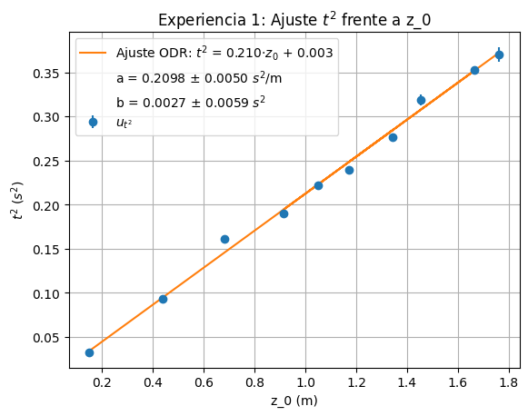

```python
fit_y = Lineal (out.beta, z_0_metros)
plt.errorbar(z_0_metros, tiempos_medios_cuadrado, yerr = u_tiempos_cuadrado, linestyle = "None", marker = "o", label = r"$u_{t^2}$")
plt.plot(z_0_metros, fit_y, label = rf'Ajuste ODR: $t^2$ = {out.beta[0]:.3f}·$z_0$ + {out.beta[1]:.3f}')
plt.plot ([], [], ' ', label = r"a = 0.2098 $\pm$ 0.0050 $s^2$/m")
plt.plot ([], [], ' ',label = r"b = 0.0027 $\pm$ 0.0059 $s^2$")
plt.title (r"Experiencia 1: Ajuste $t^2$ frente a z_0")
plt.xlabel ("z_0 (m)")
plt.ylabel (r"$t^2$ ($s^2$)")
plt.grid()
plt.legend()
plt.show()
```

### 6.2 ANEXO: EXPERIENCIA 2

```python
i = np.arange(1, 11)

z_prime = np.array([10.0, 18.9, 28.1, 36.8, 45.9, 54.9, 64.2, 73.1, 82.1, 91.2]) / 100
z = z_prime - z_prime[0] # Al ser arrays, la resta se aplica a todos los elementos

t1_prime = np.array([0.957, 1.012, 1.055, 1.090, 1.122, 1.151, 1.179, 1.204, 1.227, 1.249])
t2_prime = np.array([2.401, 2.458, 2.502, 2.538, 2.570, 2.599, 2.626, 2.650, 2.674, 2.696])
t3_prime = np.array([2.708, 2.765, 2.809, 2.845, 2.877, 2.906, 2.933, 2.958, 2.981, 3.004])

t1 = t1_prime - t1_prime[0]
t2 = t2_prime - t2_prime[0]
t3 = t3_prime - t3_prime[0]

# Matriz (3x10) de numpy porque así puedo calcular más rápido usando axis
tiempos = np.array([t1, t2, t3])
t_medio = np.mean(tiempos, axis=0)
```

```python
# n = 3 medidas por espira
u_A_t = np.std(tiempos, axis=0, ddof=1) / np.sqrt(3)

# Incertidumbre Tipo B de t (Resolución/error de lectura en Audacity)
resolucion = 0.001
# np.full_like copia el array a uno igual, en este caso copio t_medio
u_B_t = np.array([resolucion / np.sqrt(12) for i in range(len(t_medio))])
u_C_t = np.sqrt(u_A_t**2 + u_B_t**2)

print("TIEMPOS MEDIOS")
for i in range(len(t_medio)):
    print(f"\t{t_medio[i]:.6f}  +/- {u_C_t[i]:.6f} s")
```

```
TIEMPOS MEDIOS
	0.000000  +/- 0.000289 s
	0.056333  +/- 0.000726 s
	0.100000  +/- 0.001041 s
	0.135667  +/- 0.001364 s
	0.167667  +/- 0.001364 s
	0.196667  +/- 0.001364 s
	0.224000  +/- 0.001041 s
	0.248667  +/- 0.000928 s
	0.272000  +/- 0.001041 s
	0.294333  +/- 0.001236 s
```

```python
def modelo_caida(z, v0, g):
    # t = (-v0 + sqrt(v0^2 + 2*g*z)) / g
    v0_cuadrado = np.power(v0, 2)
    dos_g_z = np.multiply(2, np.multiply(g, z))
    raiz = np.sqrt(v0_cuadrado + dos_g_z)
    numerador = -v0 + raiz
    t = np.divide(numerador, g)
    return t

p0 = [1.0, 9.8]
popt, pcov = curve_fit(modelo_caida, z, t_medio, p0=p0, sigma=u_C_t, absolute_sigma=True)

v0_opt = popt[0]
g_opt = popt[1]

error_params = np.sqrt(np.diag(pcov))
v0_err = error_params[0]
g_err = error_params[1]
```

```python
print("RESULTADOS DEL AJUSTE:")
print("Velocidad inicial v0: {:.4f} +/- {:.4f} m/s".format(v0_opt, v0_err))
print("Gravedad g:           {:.4f} +/- {:.4f} m/s^2".format(g_opt, g_err))
```

```
RESULTADOS DEL AJUSTE:
Velocidad inicial v0: 1.3103 +/- 0.0206 m/s
Gravedad g:           9.8676 +/- 0.1828 m/s^2
```

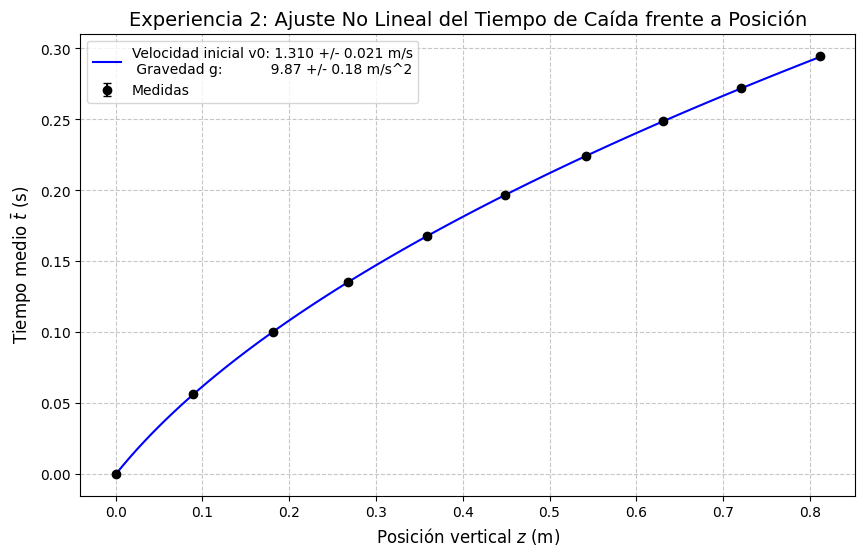

```python
# Muestro el gráfico
z_linea = np.linspace(min(z), max(z), 100)
t_linea = modelo_caida(z_linea, v0_opt, g_opt)

# 4. Creación del Plot
plt.figure(figsize=(10, 6))

# Puntos con barras de error
plt.errorbar(z, t_medio, yerr=u_C_t, fmt='o', color='black',
             ecolor='black', capsize=3, label='Medidas')

# Curva de ajuste (CORREGIDO: r antes de las comillas para LaTeX)
plt.plot(z_linea, t_linea, color='blue',
         label=f'Velocidad inicial v0: {v0_opt:.3f} +/- {round(v0_err,3)} m/s\n Gravedad g:           {g_opt:.2f} +/- {round(g_err, 2)} m/s^2')

plt.title('Experiencia 2: Ajuste No Lineal del Tiempo de Caída frente a Posición', fontsize=14)
plt.xlabel('Posición vertical $z$ (m)', fontsize=12)
plt.ylabel('Tiempo medio $\\bar{t}$ (s)', fontsize=12)
plt.grid(True, linestyle='--', alpha=0.7)
plt.legend()

plt.show()
```